# Other Research Questions

Import dataset

```r
combined_happiness = read.csv("./combined_happiness.csv") |>
  janitor::clean_names()

combined_happiness$region[combined_happiness$region == "Eastern Asian"] <- "Eastern Asia"
```

Wordmap Preparation

```r
iso_codes = countrycode::codelist[, c("un.name.en", "iso3c")]
names(iso_codes) = c("Country", "ISO3")
```

```r
world_data <- ggplot2::map_data('world')
world_data <- fortify(world_data)
```

```r
combined_happiness['ISO3'] <- iso_codes$ISO3[match(combined_happiness$country, iso_codes$Country)]
world_data["ISO3"] <- iso_codes$ISO3[match(world_data$region, iso_codes$Country)]
```

```r
combined_happiness = combined_happiness |>
  mutate(
    ISO3 = if_else(country == "United States", "USA", ISO3),
    ISO3 = if_else(country == "United Kingdom", "GBR", ISO3),
    ISO3 = if_else(country == "Venezuela", "VEN", ISO3),
    ISO3 = if_else(country == "Czech Republic", "CZE", ISO3),
    ISO3 = if_else(country == "Taiwan", "TWN", ISO3),
    ISO3 = if_else(country == "South Korea", "KOR", ISO3),
    ISO3 = if_else(country == "Bolivia", "BOL", ISO3),
    ISO3 = if_else(country == "Moldova", "MDA", ISO3),
    ISO3 = if_else(country == "Russia", "RUS", ISO3),
    ISO3 = if_else(country == "Hong Kong", "CHN", ISO3),
    ISO3 = if_else(country == "Vietnam", "VNM", ISO3),
    ISO3 = if_else(country == "Turkey", "TUR", ISO3),
    ISO3 = if_else(country == "Macedonia", "MKD", ISO3),
    ISO3 = if_else(country == "Laos", "LAO", ISO3),
    ISO3 = if_else(country == "Swaziland", "SWZ", ISO3),
    ISO3 = if_else(country == "Palestinian Territories", "PSE", ISO3),
    ISO3 = if_else(country == "Iran", "IRN", ISO3),
    ISO3 = if_else(country == "Congo (Kinshasa)", "COD", ISO3),
    ISO3 = if_else(country == "Congo (Brazzaville)", "COG", ISO3),
    ISO3 = if_else(country == "Tanzania", "TZA", ISO3),
    ISO3 = if_else(country == "Syria", "SYR", ISO3),
    ISO3 = if_else(country == "Puerto Rico", "PRI", ISO3)
  )|>
  mutate(country = recode(str_trim(country),
                         "United States" = "USA",
                         "United Kingdom" = "UK",
                         "Congo (Kinshasa)" = "Democratic Republic of the Congo",
                         "Congo (Brazzaville)" = "Republic of Congo"))
```

```r
world_data = world_data|>
  mutate(country = region)|>
  select(-region)

worldjoin <- inner_join(world_data, combined_happiness, by = "country")
```

```r
## compile all map theme configurations
cleanup <- theme(
  axis.text = element_blank(),
  axis.line = element_blank(),
  axis.ticks = element_blank(),
  panel.border = element_blank(),
  panel.grid = element_blank(),
  axis.title = element_blank(),
  panel.background = element_rect(fill = "white"),
  plot.title = element_text(hjust = 0.5)
)
```

# Q1: Which country has the highest and lowest happiness score?

In order to explore the distribution of happiness score all over the world, we draw bar charts of happiness score for each year in descending order showing different region with color and legends. We also use heat map in world map to show the geographic distribution of happiness score over the world.

## 2015

### bar chat

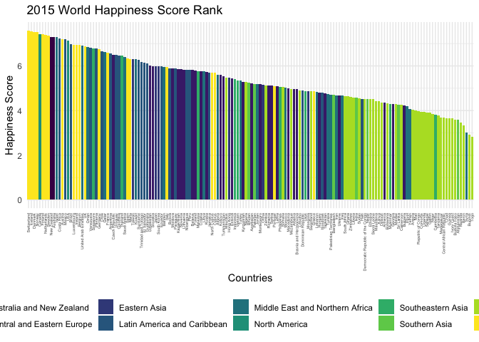

```r
combined_happiness |>
  filter(year == "2015") |>
  arrange(desc(score)) |>
  ggplot(aes(x = reorder(country, -score), y = score, fill = region)) +
  geom_bar(stat = "identity") +
  labs(title = "2015 World Happiness Score Rank", x = "Countries", y = "Happiness Score") +
  theme(axis.text.x = element_text(angle = 90, vjust = 0.5, hjust=1, size = 4)) +
  theme(legend.position = "bottom")
```

In year 2015, Switzerland has the highest happiness score while Togo has the lowest happiness score among 158 countries.

### wordmap

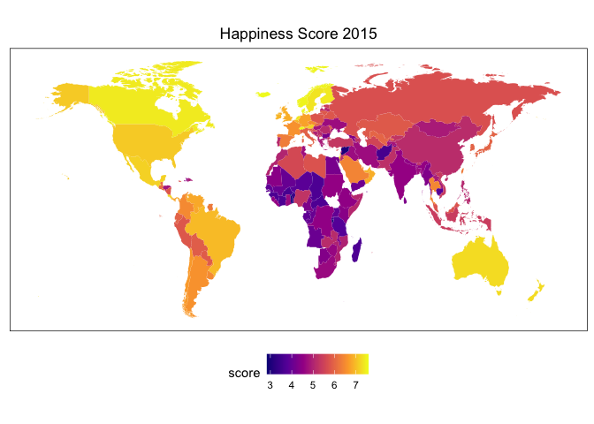

```r
hp_2015 <- worldjoin |>
  filter(year == "2015") |>
  ggplot(mapping = aes(
    x=long,
    y=lat,
    group=group)) +
  scale_fill_viridis_c(option = "C") +
  coord_fixed(1.3) +
  geom_polygon(aes(fill=score)) +
  ggtitle("Happiness Score 2015") +
  cleanup

hp_2015
```

In general, countries in Europe, Australia, North and South America have higher happiness score while countries in Africa and Middle East Asia has relatively lower happiness score in 2015.

## 2016

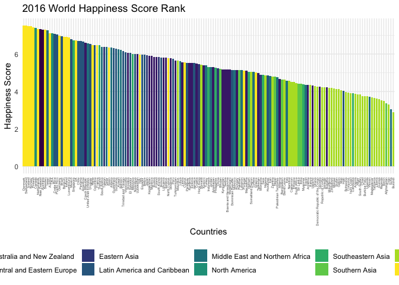

```r
combined_happiness |>
  filter(year == "2016") |>
  arrange(desc(score)) |>
  ggplot(aes(x = reorder(country, -score), y = score, fill = region)) +
  geom_bar(stat = "identity") +
  labs(title = "2016 World Happiness Score Rank", x = "Countries", y = "Happiness Score") +
  theme(axis.text.x = element_text(angle = 90, vjust = 0.5, hjust=1, size = 4)) +
  theme(legend.position = "bottom")
```

In year 2016, Denmark has the highest happiness score while Burundi has the lowest happiness score among 157 countries.

### wordmap

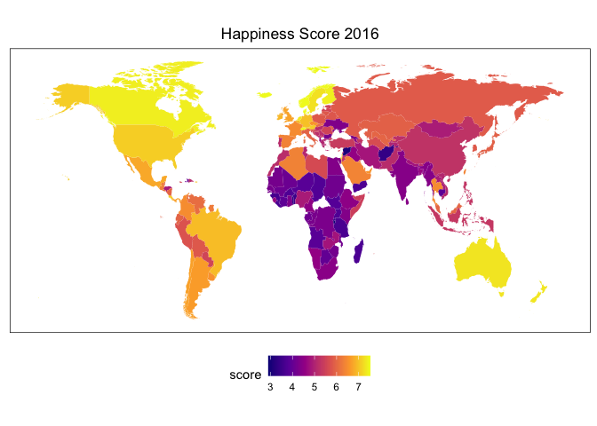

```r
hp_2016 <- worldjoin |>
  filter(year == "2016") |>
  ggplot(mapping = aes(
    x=long,
    y=lat,
    group=group)) +
  scale_fill_viridis_c(option = "C") +
  coord_fixed(1.3) +
  geom_polygon(aes(fill=score)) +
  ggtitle("Happiness Score 2016") +
  cleanup

hp_2016
```

In general, countries in Europe, Australia, North and South America have higher happiness score while countries in Africa and Middle East Asia has relatively lower happiness score in 2016.

## 2017

### bar chat

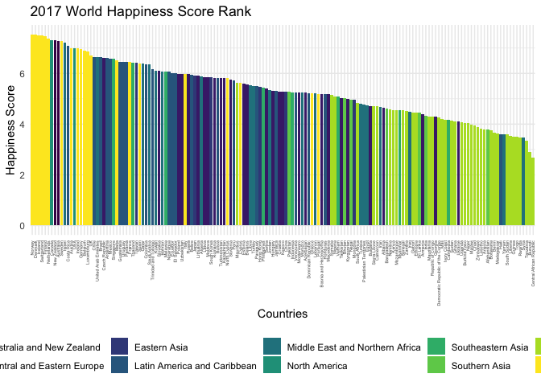

```r
combined_happiness |>
  filter(year == "2017") |>
  arrange(desc(score)) |>
  ggplot(aes(x = reorder(country, -score), y = score, fill = region)) +
  geom_bar(stat = "identity") +
  labs(title = "2017 World Happiness Score Rank", x = "Countries", y = "Happiness Score") +
  theme(axis.text.x = element_text(angle = 90, vjust = 0.5, hjust=1, size = 4)) +
  theme(legend.position = "bottom")
```

In year 2017, Norway has the highest happiness score while Central African Republic has the lowest happiness score among 155 countries.

### wordmap

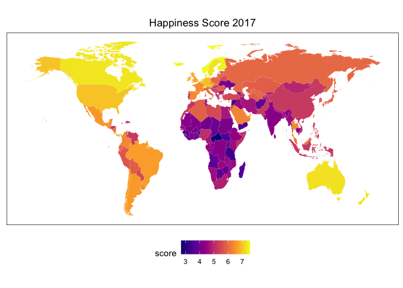

```r
hp_2017 <- worldjoin |>
  filter(year == "2017") |>
  ggplot(mapping = aes(
    x=long,
    y=lat,
    group=group)) +
  scale_fill_viridis_c(option = "C") +
  coord_fixed(1.3) +
  geom_polygon(aes(fill=score)) +
  ggtitle("Happiness Score 2017") +
  cleanup

hp_2017
```

In general, countries in Europe, Australia, North and South America have higher happiness score while countries in Africa and Middle East Asia has relatively lower happiness score in 2017.

## 2018

### bar chart

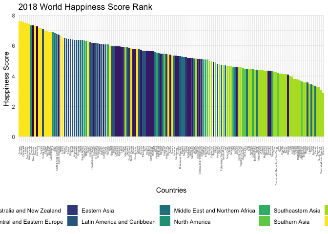

```r
combined_happiness |>
  filter(year == "2018") |>
  arrange(desc(score)) |>
  ggplot(aes(x = reorder(country, -score), y = score, fill = region)) +
  geom_bar(stat = "identity") +
  labs(title = "2018 World Happiness Score Rank", x = "Countries", y = "Happiness Score") +
  theme(axis.text.x = element_text(angle = 90, vjust = 0.5, hjust=1, size = 4)) +
  theme(legend.position = "bottom")
```

In year 2018, Finland has the highest happiness score while Burundi has the lowest happiness score among 156 countries.

### wordmap

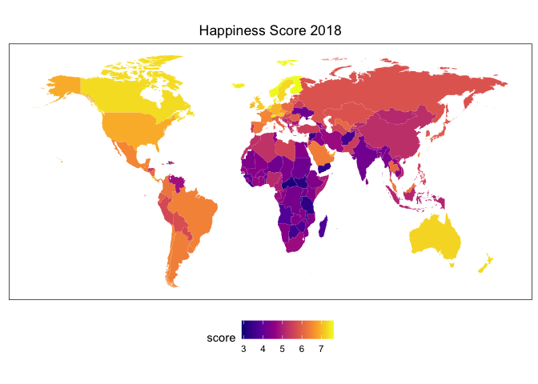

```r
hp_2018 <- worldjoin |>
  filter(year == "2018") |>
  ggplot(mapping = aes(
    x=long,
    y=lat,
    group=group)) +
  scale_fill_viridis_c(option = "C") +
  coord_fixed(1.3) +
  geom_polygon(aes(fill=score)) +
  ggtitle("Happiness Score 2018") +
  cleanup

hp_2018
```

In general, countries in Europe, Australia, North and South America have higher happiness score while countries in Africa and Middle East Asia has relatively lower happiness score in 2018.

## 2019

### bar chart

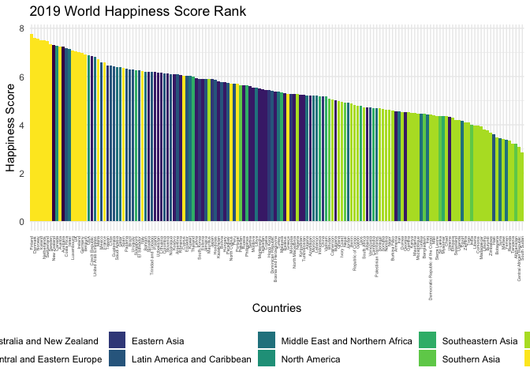

```r
combined_happiness |>
  filter(year == "2019") |>
  arrange(desc(score)) |>
  ggplot(aes(x = reorder(country, -score), y = score, fill = region)) +
  geom_bar(stat = "identity") +
  labs(title = "2019 World Happiness Score Rank", x = "Countries", y = "Happiness Score") +
  theme(axis.text.x = element_text(angle = 90, vjust = 0.5, hjust=1, size = 4)) +
  theme(legend.position = "bottom")
```

In year 2019, Finland has the highest happiness score while South Sudan has the lowest happiness score among 156 countries.

### wordmap

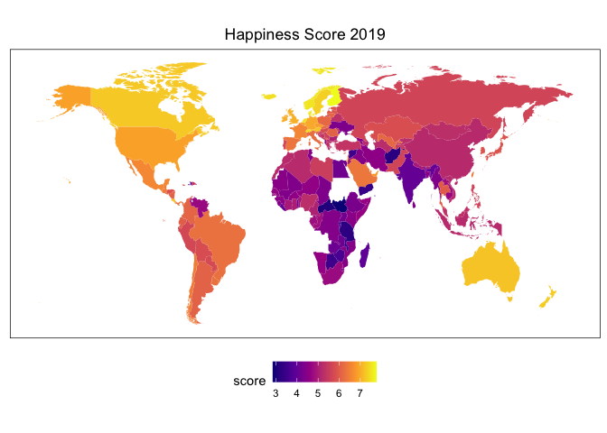

```r
hp_2019 <- worldjoin |>
  filter(year == "2019") |>
  ggplot(mapping = aes(
    x=long,
    y=lat,
    group=group)) +
  scale_fill_viridis_c(option = "C") +
  coord_fixed(1.3) +
  geom_polygon(aes(fill=score)) +
  ggtitle("Happiness Score 2019") +
  cleanup

hp_2019
```

In general, countries in Europe, Australia, North and South America have higher happiness score while countries in Africa and Middle East Asia has relatively lower happiness score in 2019.

## Average in 5 years

### bar chart

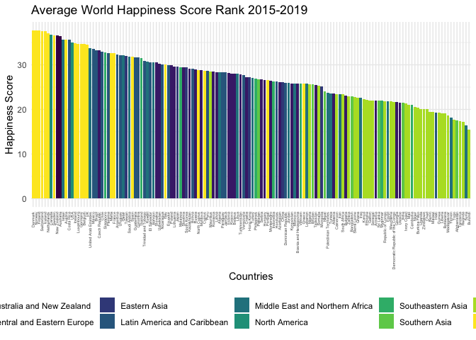

```r
hp_avg =
combined_happiness |>
  select(year, country, region, score) |>
  pivot_wider(
    names_from = "year",
    values_from = "score"
  ) |>
  na.omit() |>
  pivot_longer(
    "2015":"2019",
    names_to = "year",
    values_to = "score"
  ) |>
  group_by(year, country) |>
  mutate(score_avg = mean(score))

hp_avg|>
  arrange(desc(score_avg)) |>
  ggplot(aes(x = reorder(country, -score_avg), y = score_avg, fill = region)) +
  geom_bar(stat = "identity") +
  labs(title = "Average World Happiness Score Rank 2015-2019", x = "Countries", y = "Happiness Score") +
  theme(axis.text.x = element_text(angle = 90, vjust = 0.5, hjust=1, size = 4)) +
  theme(legend.position = "bottom")
```

We only keep countries that are in the top rank for all five years. Among those 144 countries, Danmark has the highest average happiness score while Burundi has the lowest average happiness score in 5 years.

### wordmap

```r
wold_avg <- inner_join(world_data, hp_avg, by = "country")
```

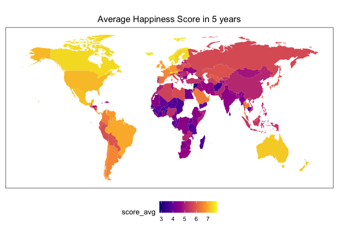

```r
hp_avg_plot <- wold_avg |>
  ggplot(mapping = aes(
    x=long,
    y=lat,
    group=group)) +
  scale_fill_viridis_c(option = "C") +
  coord_fixed(1.3) +
  geom_polygon(aes(fill=score_avg)) +
  ggtitle("Average Happiness Score in 5 years") +
  cleanup

hp_avg_plot
```

In general, countries in Europe, Australia, North and South America have higher average happiness score while countries in Africa and Middle East Asia has relatively lower average happiness score from 2015 to 2019.

The geographic distribution of World Happiness Score is stable from 2015 to 2019. European Countries such as Finland, Switzerland, and Danmark tend to have highest happiness score while African countires such as South Sudan and Central African Republic tend to have lowest happiness score. Also, countries in Europe, Australia, North and South America have higher happiness score while countries in Africa and Middle East Asia has relatively lower happiness score.

# Q2: Which region has the highest and lowest happiness score?

## 2015

### bar chat

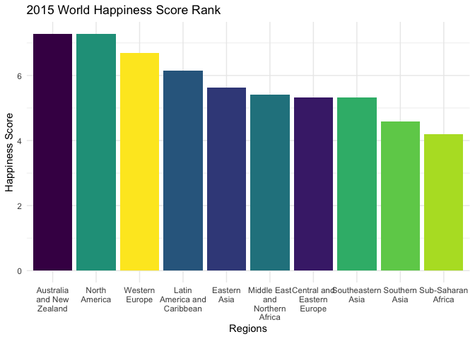

```r
combined_happiness |>
  filter(year == "2015") |>
  group_by(region) |>
  mutate(region_avg = mean(score)) |>
  arrange(desc(region_avg)) |>
  summarize(region = unique(region), score = unique(region_avg)) |>
  ggplot(aes(x = reorder(region, -score), y = score, fill = region)) +
  geom_bar(stat = "identity") +
  labs(title = "2015 World Happiness Score Rank", x = "Regions", y = "Happiness Score") +
  scale_x_discrete(labels = label_wrap_gen(width = 12)) +
  theme(legend.position = "none")
```

In year 2015, Australia and New Zealand has the highest happiness score while Sub-Saharan Africa has the lowest happiness score among 10 regions.

## 2016

### bar chart

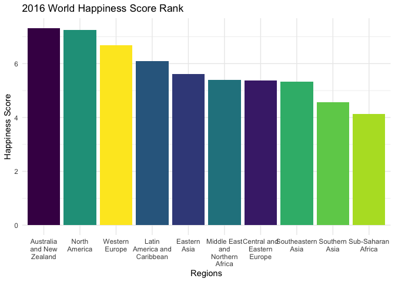

```r
combined_happiness |>
  filter(year == "2016") |>
  group_by(region) |>
  mutate(region_avg = mean(score)) |>
  arrange(desc(region_avg)) |>
  summarize(region = unique(region), score = unique(region_avg)) |>
  ggplot(aes(x = reorder(region, -score), y = score, fill = region)) +
  geom_bar(stat = "identity") +
  labs(title = "2016 World Happiness Score Rank", x = "Regions", y = "Happiness Score") +
  scale_x_discrete(labels = label_wrap_gen(width = 12)) +
  theme(legend.position = "none")
```

In year 2016, Australia and New Zealand has the highest happiness score while Sub-Saharan Africa has the lowest happiness score among 10 regions.

## 2017

### bar chat

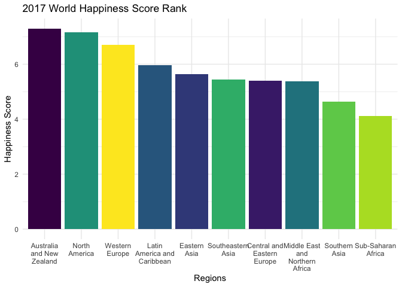

```r
combined_happiness |>
  filter(year == "2017") |>
  group_by(region) |>
  mutate(region_avg = mean(score)) |>
  arrange(desc(region_avg)) |>
  summarize(region = unique(region), score = unique(region_avg)) |>
  ggplot(aes(x = reorder(region, -score), y = score, fill = region)) +
  geom_bar(stat = "identity") +
  labs(title = "2017 World Happiness Score Rank", x = "Regions", y = "Happiness Score") +
  scale_x_discrete(labels = label_wrap_gen(width = 12)) +
  theme(legend.position = "none")
```

In year 2017, Australia and New Zealand has the highest happiness score while Sub-Saharan Africa has the lowest happiness score among 10 regions.

## 2018

### bar chart

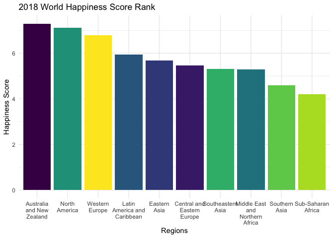

```r
combined_happiness |>
  filter(year == "2018") |>
  group_by(region) |>
  mutate(region_avg = mean(score)) |>
  arrange(desc(region_avg)) |>
  summarize(region = unique(region), score = unique(region_avg)) |>
  ggplot(aes(x = reorder(region, -score), y = score, fill = region)) +
  geom_bar(stat = "identity") +
  labs(title = "2018 World Happiness Score Rank", x = "Regions", y = "Happiness Score") +
  scale_x_discrete(labels = label_wrap_gen(width = 12)) +
  theme(legend.position = "none")
```

In year 2018, Australia and New Zealand has the highest happiness score while Sub-Saharan Africa has the lowest happiness score among 10 regions.

## 2019

### bar chart

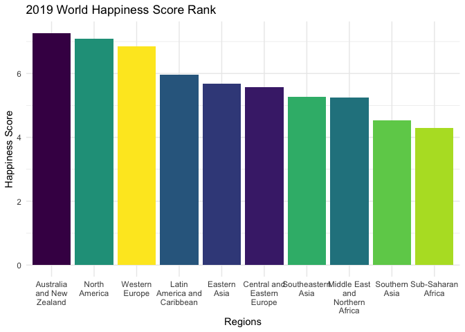

```r
combined_happiness |>
  filter(year == "2019") |>
  group_by(region) |>
  mutate(region_avg = mean(score)) |>
  arrange(desc(region_avg)) |>
  summarize(region = unique(region), score = unique(region_avg)) |>
  ggplot(aes(x = reorder(region, -score), y = score, fill = region)) +
  geom_bar(stat = "identity") +
  labs(title = "2019 World Happiness Score Rank", x = "Regions", y = "Happiness Score") +
  scale_x_discrete(labels = label_wrap_gen(width = 12)) +
  theme(legend.position = "none")
```

In year 2019, Australia and New Zealand has the highest happiness score while Sub-Saharan Africa has the lowest happiness score among 10 regions.

## Average in 5 years

### bar chart

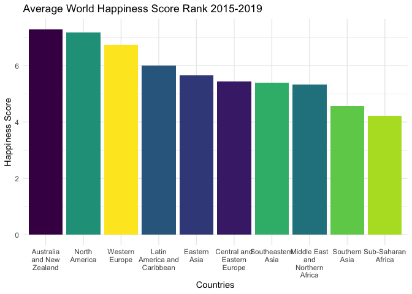

```r
hp_avg|>
  group_by(region) |>
  mutate(region_avg = mean(score)) |>
  arrange(desc(score_avg)) |>
  summarize(region = unique(region), score = unique(region_avg)) |>
  ggplot(aes(x = reorder(region, -score), y = score, fill = region)) +
  geom_bar(stat = "identity") +
  labs(title = "Average World Happiness Score Rank 2015-2019", x = "Countries", y = "Happiness Score") +
  scale_x_discrete(labels = label_wrap_gen(width = 12)) +
  theme(legend.position = "none")
```

From 2015 to 2019, Australia and New Zealand has the highest average happiness score while Sub-Saharan Africa has the lowest average happiness score among 10 regions.

# Q3: What are some trends of mean happiness score in different regions from 2015 – 2019?

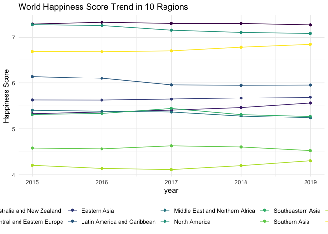

```r
combined_happiness |>
  group_by(year, region) |>
  mutate(region_avg = mean(score)) |>
  arrange(desc(region_avg)) |>
  summarize(region = unique(region), score = unique(region_avg)) |>
  ggplot(aes(x = year, y = score, color = region)) +
  geom_point() +
  geom_line() +
  labs(title = "World Happiness Score Trend in 10 Regions", x = "year", y = "Happiness Score")
```